# Hypothesis_and_Inference(Ch7)

```python
from math import *
```

```python
from collections import Counter
```

```python
def normal_pdf(x, mu=0, sigma=1):
    sqrt_two_pi = sqrt(2 * pi)
    return (exp(-(x-mu) ** 2 / 2 / sigma ** 2) / (sqrt_two_pi * sigma))
```

```python
def normal_cdf(x, mu=0,sigma=1):
    return (1 + erf((x - mu) / sqrt(2) / sigma)) / 2
```

```python
from matplotlib import pyplot as plt
```

```python
%matplotlib inline
```

```python
def inverse_normal_cdf(p, mu=0, sigma=1, tolerance=0.00001):
    """find approximate inverse using binary search"""
    # if not standard, compute standard and rescale
    if mu != 0 or sigma != 1:
        return mu + sigma * inverse_normal_cdf(p, tolerance=tolerance)
    low_z, low_p = -10.0, 0 # normal_cdf(-10) is (very close to) 0
    hi_z, hi_p = 10.0, 1 # normal_cdf(10) is (very close to) 1
    while hi_z - low_z > tolerance:
        mid_z = (low_z + hi_z) / 2 # consider the midpoint
        mid_p = normal_cdf(mid_z) # and the cdf's value there
        if mid_p < p:
        # midpoint is still too low, search above it
            low_z, low_p = mid_z, mid_p
        elif mid_p > p:
        # midpoint is still too high, search below it
            hi_z, hi_p = mid_z, mid_p
        else:
            break
    return mid_z
```

```python
def normal_approximation_to_binomial(n, p):
    """finds mu and sigma corresponding to a Binomial(n, p)"""
    mu = p * n
    sigma = sqrt(p * (1 - p) * n)
    return mu, sigma
```

```python
# the normal cdf _is_ the probability the variable is below a threshold
normal_probability_below = normal_cdf
# it's above the threshold if it's not below the threshold
def normal_probability_above(lo, mu=0, sigma=1):
    return 1 - normal_cdf(lo, mu, sigma)
# it's between if it's less than hi, but not less than lo
def normal_probability_between(lo, hi, mu=0, sigma=1):
    return normal_cdf(hi, mu, sigma) - normal_cdf(lo, mu, sigma)
# it's outside if it's not between
def normal_probability_outside(lo, hi, mu=0, sigma=1):
    return 1 - normal_probability_between(lo, hi, mu, sigma)
```

```python
def normal_upper_bound(probability, mu=0, sigma=1):
    """returns the z for which P(Z <= z) = probability"""
    return inverse_normal_cdf(probability, mu, sigma)
def normal_lower_bound(probability, mu=0, sigma=1):
    """returns the z for which P(Z >= z) = probability"""
    return inverse_normal_cdf(1 - probability, mu, sigma)
def normal_two_sided_bounds(probability, mu=0, sigma=1):
    """returns the symmetric (about the mean) bounds
    that contain the specified probability"""
    tail_probability = (1 - probability) / 2
    # upper bound should have tail_probability above it
    upper_bound = normal_lower_bound(tail_probability, mu, sigma)
    # lower bound should have tail_probability below it
    lower_bound = normal_upper_bound(tail_probability, mu, sigma)
    return lower_bound, upper_bound
```

```python
mu_0, sigma_0 = normal_approximation_to_binomial(1000, 0.5)
```

```python
normal_two_sided_bounds(0.95, mu_0, sigma_0)
```

```
(469.01026640487555, 530.9897335951244)
```

```python
# 95% bounds based on assumption p is 0.5
lo, hi = normal_two_sided_bounds(0.95, mu_0, sigma_0)
# actual mu and sigma based on p = 0.55
mu_1, sigma_1 = normal_approximation_to_binomial(1000, 0.55)
```

```python
type_2_probability = normal_probability_between(lo, hi, mu_1, sigma_1)
```

```python
type_2_probability
```

```
0.11345199870463285
```

```python
power = 1-type_2_probability
```

```python
power
```

```
0.8865480012953671
```

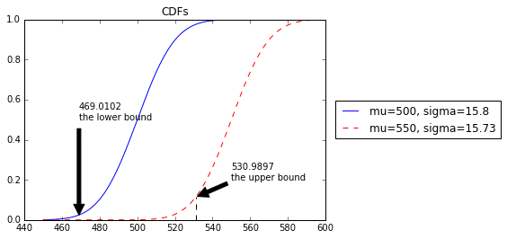

```python
xs = [x for x in range(450, 600)]
plt.plot(xs, [normal_cdf(x, mu_0, sigma_0) for x in xs], '-', label='mu=500, sigma=15.8')
plt.plot(xs, [normal_cdf(x, mu_1, sigma_1) for x in xs], 'r--', label='mu=550, sigma=15.73')
plt.plot((531, 531), (0.0, 0.11345), 'k--')
plt.plot((469, 469), (0.0, 0), 'k-')
plt.title("CDFs")
plt.legend(loc="center right", bbox_to_anchor=(1.6, 0.5))
plt.annotate('530.9897\nthe upper bound', xy=(530.9897, 0.1134),xytext=(550, 0.2),arrowprops=dict(facecolor='black', shrink=0.05))
plt.annotate('469.0102\nthe lower bound', xy=(469.0102, 0),xytext=(469, 0.5),arrowprops=dict(facecolor='black', shrink=0.05))
```

So, the probability of finding a value between (469.01026640487555, 530.9897335951244) when mu is 550 and sigma = 15.73 is 0.11345...

To illustrate, this probability of 0.11345.. is the probability of not rejecting the hypothesis that mu is 500, while the true mu is not 500 (550 here, but could be any value other than 500).

This probability is the crudely colored area on the pdf below.

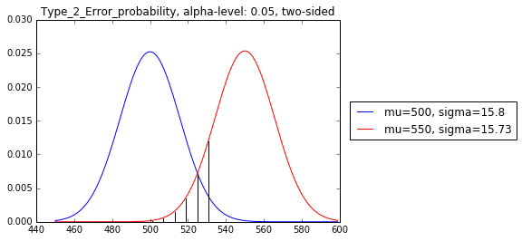

```python
xs = [x for x in range(450, 600)]
plt.plot(xs, [normal_pdf(x, mu_0, sigma_0) for x in xs], '-', label='mu=500, sigma=15.8')
plt.plot(xs, [normal_pdf(x, mu_1, sigma_1) for x in xs], 'r-', label='mu=550, sigma=15.73')
plt.plot((531, 531), (0.0, 0.012), 'k-')
plt.plot((525, 525), (0.0, 0.007), 'k-')
plt.plot((519, 519), (0.0, 0.0035), 'k-')
plt.plot((513, 513), (0.0, 0.0015), 'k-')
plt.plot((507, 507), (0.0, 0.0005), 'k-')
plt.plot((501, 501), (0.0, 0.00005), 'k-')


plt.title("Type_2_Error_probability, alpha-level: 0.05, two-sided")
plt.legend(loc="center right", bbox_to_anchor=(1.6, 0.5))
```

```python
hi = normal_upper_bound(0.95, mu_0, sigma_0)
```

```python
hi
```

```
526.0073585242053
```

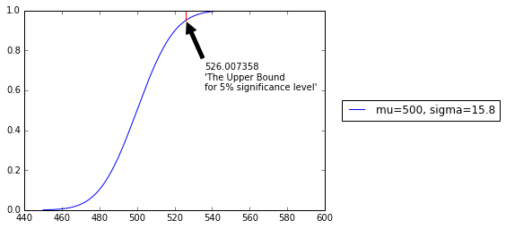

```python
xs = [x for x in range(450, 600)]
plt.plot(xs, [normal_cdf(x, mu_0, sigma_0) for x in xs], '-', label='mu=500, sigma=15.8')
plt.plot((526, 526), (0.95, 1.0), 'r-')
plt.legend(loc="center right", bbox_to_anchor=(1.6, 0.5))
plt.annotate("526.007358\n'The Upper Bound\nfor 5% significance level'", xy=(526.007358, 0.95), xytext=(536, 0.6), arrowprops=dict(facecolor='black', shrink=0.05))
```

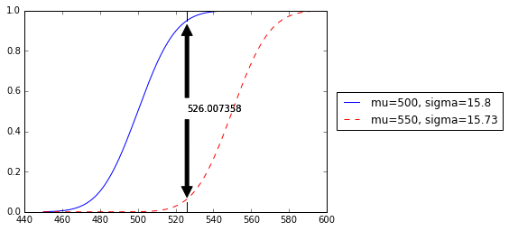

```python
xs = [x for x in range(450, 600)]
plt.plot(xs, [normal_cdf(x, mu_0, sigma_0) for x in xs], '-', label='mu=500, sigma=15.8')
plt.plot(xs, [normal_cdf(x, mu_1, sigma_1) for x in xs], 'r--', label='mu=550, sigma=15.73')
plt.plot((526, 526), (0.95, 1.0), 'k-')
plt.plot((526, 526), (0.0, 0.05), 'k-')
plt.legend(loc="center right", bbox_to_anchor=(1.6, 0.5))
plt.annotate("526.007358", xy=(526.007358, 0.95), xytext=(526, 0.5), arrowprops=dict(facecolor='black', shrink=0.05))
plt.annotate("526.007358", xy=(526.007358, 0.05), xytext=(526, 0.5), arrowprops=dict(facecolor='black', shrink=0.05))
```

```python
type_2_probability = normal_probability_below(hi, mu_1, sigma_1)
```

```python
type_2_probability
```

```
0.06362051966928273
```

```python
power = 1 - type_2_probability
```

```python
power
```

```
0.9363794803307173
```

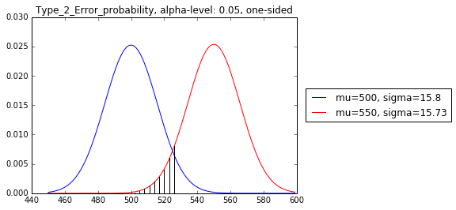

```python
xs = [x for x in range(450, 600)]
plt.plot(xs, [normal_pdf(x, mu_0, sigma_0) for x in xs], '-', label='mu=500, sigma=15.8')
plt.plot(xs, [normal_pdf(x, mu_1, sigma_1) for x in xs], 'r-', label='mu=550, sigma=15.73')
plt.plot((526, 526), (0.0, 0.008), 'k-')
plt.plot((523, 523), (0.0, 0.006), 'k-')
plt.plot((520, 520), (0.0, 0.004), 'k-')
plt.plot((517, 517), (0.0, 0.0028), 'k-')
plt.plot((514, 514), (0.0, 0.002), 'k-')
plt.plot((511, 511), (0.0, 0.0013), 'k-')
plt.plot((508, 508), (0.0, 0.0008), 'k-')
plt.plot((505, 505), (0.0, 0.0004), 'k-')
plt.plot((502, 502), (0.0, 0.00015), 'k-')


plt.title("Type_2_Error_probability, alpha-level: 0.05, one-sided")
plt.legend(loc="center right", bbox_to_anchor=(1.6, 0.5))
```

How should we interpret the increase of power? (0.89 -> 0.94) The null hypothesis ($H_0$) has now been modified from p = 0.5 to p <= 0.5. We will regard any value of p, the ratio of heads to 1,000 coin flips, less than 0.5 as acceptable. However, the likelihood of observing p larger than 0.5 will decrease as p grows closer to 1.

When $H_0$: p = 0.5 (equivalent to mu = 500), it is supposed that any value of p (don't be confused with p-value, another statistical concept) significantly smaller or larger than 0.5 is considered as 'unlikely' (Two-sided). The degree of 'significance' is set by '$\alpha$'.

The $\alpha$ can be thought of as our confidence over a hypothesis, or a hypothesized parameter value. It shows how much we are willing to admit that our hypothesis is true. In our example ($H_0$: p = 0.5), $\alpha$ = 0.05 means that we suppose that the ratio of the number of heads to 1,000 coin flips is 2.5% likely to exceed 0.531. In other words, the cumulated probability of observing values of p above the hypothesized mean (0.5) by 1.96 x sigma (0.5 / sqrt(1000)) or greater is 0.025. At the same time, the ratio is 2.5% likely to go below 0.469. Similarly, the cumulated probability of observing values of p below the hypothesized mean by the same amount or greater, once $H_0$ is true, would be 0.025. The sum of the cumulated probabilities equals 0.05, $\alpha$. This 0.05 is equal to the sum of the area under pdf at (-inf, hypothesized mean - 1.96 x sigma) and (hypothesized mean + 1.96 x sigma, inf), each of which is 0.025.

Thus, we are going to reject $H_0$ if a value of p is observed outside the range (0.469, 0.531) among a numerous number of 1,000 coin flips. Why would we hold onto a hypothesis that is not likely to predict what we have found? Wouldn't it be better to find another hypothesis that is more likely to accomodate what we have observed?

In contrast, when $H_0$: p <= 0.5, observing a value smaller than 0.5 does not matter to the level of $\alpha$. Only a value of p larger than 0.5 is of interest (One-sided). Therefore, 5% of $\alpha$ level is equal to the area under pdf at (hypothesized mean + 1.64 x sigma, inf). The upper bound of 'one-sided' should, consequently, be smaller than that of 'two-sided'.

Now, $\beta$ is not something we could decide. It highly depends on the true value of p. In our example, it could be understood like this:

Suppose the p is not 0.5. Therefore, we bring an alternative hypothesis, $H_1$: p = 0.55. On the above pdf plot, this alternative pdf is the red curve. The thing is, we never know what the true p is. $H_1$ could be p = 0.53, p = 51, or whatever you may think of. The condition for $H_1$ is p other than 0.5.

Let's say that we just stick to our null hypothesis first.

Under $H_0$: p = 0.5 and $\alpha$ = 0.05, we don't reject that hypothesis when a value of p is within the range (0.469, 0.531). This range can also be observed with the red pdf, since every pdf's range is (-inf, inf). Now, with the alternative hypothesis ($H_1$), how much are we likely to observe a value of p within this range? Calculating the normal probability between 0.469 and 0.531, with our true parameters (p = 0.55 / mu = 550, sigma = 15.73), will give us the answer. In this case, $\beta$ = 0.113, power = 1-$\beta$ = 0.887.

$\beta$ may be, therefore, the probability that we don't reject our null hypothesis, even though it is false. This being 'false' is represented by calculating the cumulative probability of our alternative hypothesis, $H_1$. Consequently, 'power' is the probability that we choose the alternative hypothesis given that it is 'true'.

Wait, but what happens if $H_1$: p = 0.53?

```python
mu_2, sigma_2 = normal_approximation_to_binomial(1000, 0.53)
```

```python
sigma_2
```

```
15.782902141241324
```

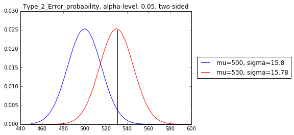

```python
xs = [x for x in range(450, 600)]
plt.plot(xs, [normal_pdf(x, mu_0, sigma_0) for x in xs], '-', label='mu=500, sigma=15.8')
plt.plot(xs, [normal_pdf(x, mu_2, sigma_2) for x in xs], 'r-', label='mu=530, sigma=15.78')
plt.plot((531,531), (0.0, 0.025), 'k-')
plt.title("Type_2_Error_probability, alpha-level: 0.05, two-sided")
plt.legend(loc="center right", bbox_to_anchor=(1.6, 0.5))
```

```python
normal_probability_between(469, 531, mu_2, sigma_2)
```

```
0.5252044048311235
```

Now, beta is 0.525, and power shrinks to 1-0.5252 = 0.4748. The new probability of rejecting the null hypothesis, once the alternative hypothesis is true, is 0.4748.

See the peak of the two pdfs. The peak on the left stands for what we believe to be a true mean. The peak on the right is a 'maybe-closer-to-the-true-mean' mean. Then, when the distance between the two peaks is close, we are less likely to reject our null hypothesis, even though it is not true. In other words, we don't see the difference between our hypothesized mean and the 'maybe' true mean that big, and are not very 'persuaded' to by the alternative hypothesis about the true mean.

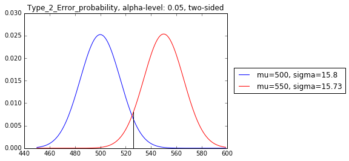

```python
xs = [x for x in range(450, 600)]
plt.plot(xs, [normal_pdf(x, mu_0, sigma_0) for x in xs], '-', label='mu=500, sigma=15.8')
plt.plot(xs, [normal_pdf(x, mu_1, sigma_1) for x in xs], 'r-', label='mu=550, sigma=15.73')
plt.plot((526, 526), (0.0, 0.008), 'k-')

plt.title("Type_2_Error_probability, alpha-level: 0.05, two-sided")
plt.legend(loc="center right", bbox_to_anchor=(1.6, 0.5))
```

Ok, let's get back to the difference of power between the one-sided test and the two-sided test.

If $H_0$: p <= 0.5 and $\alpha$ = 0.05, we don't reject that hypothesis when a value of p is within the range (-inf, 0.526). What's the probability of observing a value of p within this range now in a pdf of p = 0.55? It is given by the normal probability between -inf and 0.526. The result is $\beta$ = 0.063, power = 0.94.

A two-sided test considers either direction, and thus makes the area overlapped between the two pdf curves larger by pushing either the lower bound or the upper one of the null hypothesis toward the alternative hypothesis. The larger area overlapped, the more probability the alternative hypothesis should forsake even though it may be a true one.

On the contrary, a one-sided test deals with one direction, and makes the area overlapped smaller by pulling either the lower bound or the upper bound toward the null hypothesis.

Nonetheless, this also depends on which direction you do the one-sided test. Let's check if the true p is less than 0.5, and the same applies.

```python
mu_3, sigma_3 = normal_approximation_to_binomial(1000, 0.45)
```

```python
sigma_3
```

```
15.732132722552274
```

```python
type_2_probability = normal_probability_between(469, 531, mu_3, sigma_3)
```

[figure not shown]

```python
xs = [x for x in range(400, 550)]
plt.plot(xs, [normal_pdf(x, mu_0, sigma_0) for x in xs], '-', label='mu=500, sigma=15.8')
plt.plot(xs, [normal_pdf(x, mu_3, sigma_3) for x in xs], 'r-', label='mu=480, sigma=15.73')
plt.plot((469, 469), (0.0, 0.0115), 'k-')

plt.title("Type_2_Error_probability, alpha-level: 0.05, two-sided")
plt.legend(loc="center right", bbox_to_anchor=(1.6, 0.5))
```

```python
power = 1-type_2_probability
```

```python
power
```

```
0.886422501395652
```

```python
# Let's do the one-sided test. H_0: p >= 0.5
lo = normal_lower_bound(0.95, mu_0, sigma_0)
```

```python
lo
```

```
473.99264147579476
```

This lo means that under the null hypothesis, if 474 heads or less are observed in one trial of 1,000 coin flips, we are going to reject the null hypothesis.

```python
type_2_probability = normal_probability_above(lo, mu_3, sigma_3)
```

```python
power = 1-type_2_probability
```

```python
power
```

```
0.9363794803307176
```

We can see that the power has increased from 0.886 to 0.936.

What happens to power if the bound of our null hypothesis gets even further away from the true mean by doing the one-sided test in a wrong direction? Does it grow bigger?

```python
# One-sided test, H_0: p <= 0.5
type_2_probability = normal_probability_above(hi, mu_3, sigma_3)
```

```python
power = 1-type_2_probability
```

```python
power
```

```
0.9999993219306429
```

Now that we have observed few things regarding $\alpha$ and power, how can we increase statistical power?

See how wikepedia has summarized few factors that influence statistical power. https://en.wikipedia.org/wiki/Statistical_power#Factors_influencing_power

```python
mu_4, sigma_4 = normal_approximation_to_binomial(100, 0.5)
```

```python
mu_5, sigma_5 = normal_approximation_to_binomial(100, 0.55)
```

```python
sigma_5
```

```
4.9749371855331
```

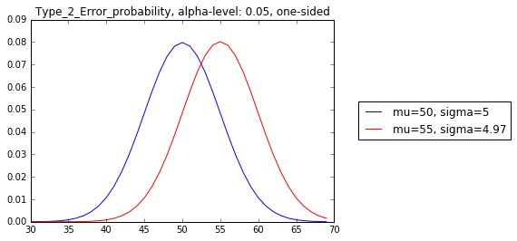

```python
xs = [x for x in range(30, 70)]
plt.plot(xs, [normal_pdf(x, mu_4, sigma_4) for x in xs], '-', label='mu=50, sigma=5')
plt.plot(xs, [normal_pdf(x, mu_5, sigma_5) for x in xs], 'r-', label='mu=55, sigma=4.97')

plt.title("Type_2_Error_probability, alpha-level: 0.05, one-sided")
plt.legend(loc="center right", bbox_to_anchor=(1.6, 0.5))
```

See how much the two curves have become closer, compared to n = 1000? If this is the case, power will obviously decrease. Let's calculate them.

```python
lo, hi = normal_two_sided_bounds(0.95, mu_4, sigma_5)
```

```python
hi
```

```
59.750692039100706
```

Now, (40.25, 59.75) is the range where null hypothesis will not be rejected, even if it is false. At a glance, the two curves overlap very much in this range.

```python
type_2_probability = normal_probability_between(lo, hi, mu_5, sigma_5)
```

```python
power = 1 - type_2_probability
```

```python
power
```

```
0.17132121697585834
```

Oh my, this is cruel. The probability of choosing the alternative hypothesis, given that it is true, is only 0.17. This means that we will stubbornly stick to the null hypothesis even if it is false. Ha!

```python
def two_sided_p_value(x, mu=0, sigma=1):
    if x >= mu:
        # if x is greater than the mean, the tail is what's greater than x
        return 2 * normal_probability_above(x, mu, sigma)
    else:
        # if x is less than the mean, the tail is what's less than x
        return 2 * normal_probability_below(x, mu, sigma)
```

```python
two_sided_p_value(529.5, mu_0, sigma_0)
```

```
0.06207721579598857
```

```python
from random import *
```

```python
extreme_value_count = 0
for _ in range(100000):
    num_heads = sum(1 if random() < 0.5 else 0 for _ in range(1000))
    if num_heads >= 530 or num_heads <= 470:
        extreme_value_count += 1
print(extreme_value_count / 100000)
```

```
0.06114
```

```python
two_sided_p_value(531.5, mu_0, sigma_0)
```

```
0.046345287837786575
```

```python
upper_p_value = normal_probability_above
lower_p_value = normal_probability_below
```

```python
upper_p_value(524.5, mu_0, sigma_0)
```

```
0.06062885772582083
```

```python
lower_p_value(469, mu_0, sigma_0)
```

```
0.024962142019848865
```

```python
p_hat = 525/1000
```

```python
mu = p_hat
```

```python
sigma = sqrt(p_hat*(1-p_hat)/1000)
```

```python
normal_two_sided_bounds(0.95, mu, sigma)
```

```
(0.4940490278129096, 0.5559509721870904)
```

```python
p_hat = 540/1000
mu = p_hat
sigma = sqrt(p_hat*(1-p_hat)/1000)
normal_two_sided_bounds(0.95, mu, sigma)
```

```
(0.5091095927295919, 0.5708904072704082)
```

```python
def run_experiment():
    return [random() <0.5 for _ in range(1000)]
```

```python
def reject_fairness(experiment):
    """using the 5% significance levels"""
    num_heads = len([flip for flip in experiment if flip])
    return num_heads < 469 or num_heads > 531
```

```python
seed(0)
experiments = [run_experiment() for _ in range(1000)]
num_rejections = len([experiment for experiment in experiments if reject_fairness(experiment)])
```

```python
print(num_rejections)
```

```
46
```

```python
def estimated_parameters(N, n):
    p = n/N
    sigma = sqrt(p*(1-p) / N)
    return p, sigma
```

```python
def a_b_test_statistic(N_A, n_A, N_B, n_B):
    p_A, sigma_A = estimated_parameters(N_A, n_A)
    p_B, sigma_B = estimated_parameters(N_B, n_B)
    return (p_B - p_A) / sqrt(sigma_A**2 + sigma_B**2)
```

The null hypothesis($H_0$) is that $p_A$ and $p_B$ are the same, or $p_A - p_B$ is zero.

```python
z = a_b_test_statistic(1000, 200, 1000, 180)
z
```

```
-1.1403464899034472
```

z should approximately be a standard normal, because z static has been calculated as $z = \frac{X - \mu}{\sigma}$, where $\mu$ is zero.

Now, under the pdf of zero mean and standard deviation $\sqrt{(\sigma_{A}^2 + \sigma_{B}^2)}$, z may be observed with certain probability. What would be that probability?

```python
two_sided_p_value(z)
```

```
0.254141976542236
```

This is way over p = 0.05. Hence, we could not reject $H_0: p_A - p_B = 0$

If the disparity between $p_A$ and $p_B$ gets larger, it would bring out a different result

```python
z = a_b_test_statistic(1000, 200, 1000, 150)
z
```

```
-2.948839123097944
```

```python
two_sided_p_value(z)
```

```
0.003189699706216853
```

```python
def B(alpha, beta):
    """a normalizing constant so that the total probability is 1"""
    return gamma(alpha) * gamma(beta) / gamma(alpha + beta)
def beta_pdf(x, alpha, beta):
    if x < 0 or x > 1: # no weight outside of [0, 1]
        return 0
    return x ** (alpha - 1) * (1 - x) ** (beta - 1) / B(alpha, beta)
```

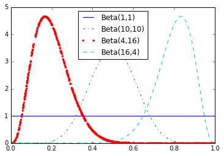

```python
xs = [x for x in sorted([random() for i in range(1000)])]
plt.plot(xs, [beta_pdf(x, 1, 1) for x in xs], 'b-', label='Beta(1,1)')
plt.plot(xs, [beta_pdf(x, 10, 10) for x in xs], 'g-.', label='Beta(10,10)')
plt.plot(xs, [beta_pdf(x, 4, 16) for x in xs], 'r.', label='Beta(4,16)')
plt.plot(xs, [beta_pdf(x, 16, 4) for x in xs], 'c--', label='Beta(16,4)')
plt.legend(loc=9)
```

```python
def bernoulli_trial(p):
    return 1 if random() < p else 0
def binomial(n, p):
    return sum(bernoulli_trial(p) for _ in range(n))
```

```python
# This is a function that calculates the posterior distribution
# calculated by the product of a beta prior and a binomial likelihood function
# The parameters are:
# x = an estimate probability in (0,1)
# y = a random variable of a binomial likelihood function
# n = the total number of trials of a binomial likelihood function
# alpha, beta = parameters of a beta distribution
def binom_posterior_pdf(x, y, n, alpha, beta):
    normalizer = gamma(y+alpha)*gamma(n-y+beta)/gamma(n+alpha+beta)
    return x**(y+alpha-1)*(1-x)**(n-y+beta-1) / normalizer
```

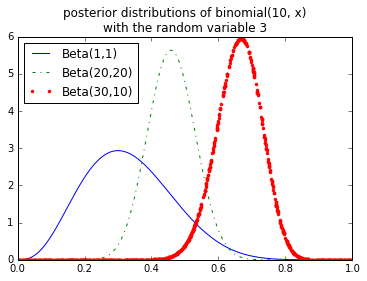

```python
# Here we plot the posterior distributions of the probabilities of heads.
# We flip the coin 10 times(n) and see only 3 heads(y).
# See which probability value(x) is most likely,
# given our prior belief(alpha, beta) and the likelihood function.

xs = [x for x in sorted([random() for i in range(1000)])]
# Beta(1,1) is a uniform distribution.
plt.plot(xs, [binom_posterior_pdf(x, 3, 10, 1, 1) for x in xs], 'b-', label='Beta(1,1)')
# Beta(20,20) expresses the belief that the coin was roughly fair.
plt.plot(xs, [binom_posterior_pdf(x, 3, 10, 20, 20) for x in xs], 'g-.', label='Beta(20,20)')
# Beta(30,10) expresses the belief that the coin was biased to flip 75% heads.
plt.plot(xs, [binom_posterior_pdf(x, 3, 10, 30, 10) for x in xs], 'r.', label='Beta(30,10)')
plt.title('posterior distributions of binomial(10, x)\nwith the random variable 3')
plt.legend(loc = 2)
```

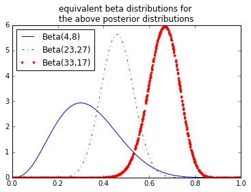

```python
xs = [x for x in sorted([random() for i in range(1000)])]
plt.plot(xs, [beta_pdf(x, 4, 8) for x in xs], 'b-', label='Beta(4,8)')
plt.plot(xs, [beta_pdf(x, 23, 27) for x in xs], 'g-.', label='Beta(23,27)')
plt.plot(xs, [beta_pdf(x, 33, 17) for x in xs], 'r.', label='Beta(33,17)')
plt.title('equivalent beta distributions for \nthe above posterior distributions')
plt.legend(loc=2)
```

Do you see that the plot above and below are roughly the same? This was done to prove the book's claim that calculated posterior distributions will each be Beta(4,8), Beta(23, 27), and Beta(33, 17). The book was telling the truth!